# Simulating disease transmission using different timesteps

Edie Bishop

8th of November 2019

# Introduction

In this script we call on a simple population dynamics model (step_deterministic_SIS), which takes a value for disease transmission rate, and a value for recovery rate, and returns a dataframe containing counts of susceptible and infection individuals. The model can be represented by the following mathematical equations:
$$S(t + 1) = S(t) - \beta * S(t) * I(t) / N + \sigma * I(t)$$
$$I(t + 1) = I(t) + \beta * S(t) * I(t) / N - \sigma * I(t)$$
*Where S = susceptible animals, I = infected animals, t = time, $\beta$ = transmission rate & $\sigma$* *= recovery rate*

We will use this model to simulate a disease outbreak of *Escherichia coli* in a herd of cattle, using differing timesteps to determine which value for timesteps would be appropriate to simulate this disease outbreak.

### Source our functions

```r
source("0301_plot_helper.R")
source("0301_step_SIS.R")
```

### Define parameters

To start with we define the population size and the transmission and recovery rates, in this case for E. coli infection in a herd of cattle.

```r
num.cattle <- 100
initial.infected <- 2
initial.susceptible <- num.cattle - initial.infected
```

Next we define our dataframe, herd.df.x, which contians two columns: number of susceptible cattle and number of infected cattle. Each dataframe will correspond to a differnt timestep value.

```r
herd.df <- data.frame(SUSCEPTIBLES = initial.susceptible,
                      INFECTED = initial.infected)
herd.df.a <- data.frame(SUSCEPTIBLES = initial.susceptible,
                        INFECTED = initial.infected)
herd.df.b <- data.frame(SUSCEPTIBLES = initial.susceptible,
                        INFECTED = initial.infected)
herd.df.c <- data.frame(SUSCEPTIBLES = initial.susceptible,
                        INFECTED = initial.infected)
```

In this exercise we will run the model over different timesteps. The default timestep, which the transmission rate for E. coli in cattle is generally given in, is one week. Therefore, we will first run the simulation using one week timesteps, followed by one day, then eight weeks then 20 weeks.

```r
timestep.a <- 1/7
timestep.b <- 8
timestep.c <- 20
```

Then we define the transmission rate and the recovery rate for E. coli infection.

```r
ecoli.transmission <- 2/3
ecoli.recovery <- 1/3
```

Then we define the start time and the end time for our study.

```r
start.time <- 0
end.time <- 200
```

### Run the function

Now we loop through the time itself (starting at the second time step). The for() command creates the loop, and then we call our function, step_deterministic_SIS(), which creates a new value for susceptiple and infected cattle at each time step. We call the funtion four times, in order to model each of the different timestep values. We will start by running the simulation without specifying “timestep”, therefore each timestep will be the default of one week.

```r
timesteps <- seq(from = start.time + 1, to = end.time)

for(new.time in timesteps) {
  ## Calculate the changes to the herd using or step_deterministic_SIS() function
  updated.population <- step_deterministic_SIS(latest=tail(herd.df, 1),
                                               transmission.rate = ecoli.transmission,
                                               recovery.rate = ecoli.recovery)
  ## Then define the herd.df dataframe, which is the herd.df dataframe with the updated.population
  ## dataframe appended to the end of it.
  herd.df <- rbind(herd.df, updated.population)
}
```

We need to add another column (time) to our population.df dataframe, so that we can make a plot of population againsts time. We do this by using c() to add start.time and timesteps to the dataframe in a newly defined column below:

```r
herd.df$time <- c(start.time, timesteps)
```

We then use timestep.a to define a new variable, timesteps.a, which will tell the function that we want to simulate the population at each day.

```r
timesteps.a <- seq(from = start.time + timestep.a, to = end.time, by = timestep.a)

for(new.time in timesteps.a) {
  updated.population <- step_deterministic_SIS(latest=tail(herd.df.a, 1),
                                               transmission.rate = ecoli.transmission * timestep.a,
                                               recovery.rate = ecoli.recovery * timestep.a)
  herd.df.a <- rbind(herd.df.a, updated.population)
}
herd.df.a$time <- c(start.time, timesteps.a)
```

We then do the same again, this time using timestep.b = 8 to run the simulation with eight-weekly timesteps

```r
timesteps.b <- seq(from = start.time + timestep.b, to = end.time, by = timestep.b)
for(new.time in timesteps.b) {
  updated.population <- step_deterministic_SIS(latest=tail(herd.df.b, 1),
                                               transmission.rate = ecoli.transmission * timestep.b,
                                               recovery.rate = ecoli.recovery * timestep.b)
  herd.df.b <- rbind(herd.df.b, updated.population)
}
herd.df.b$time <- c(start.time, timesteps.b)
```

We do the same again, using timestep.c = 20, which will mean we model the tranmission in 20 week intervals

```r
timesteps.c <- seq(from = start.time + timestep.c, to = end.time, by = timestep.c)
for(new.time in timesteps.c) {
  updated.population <- step_deterministic_SIS(latest=tail(herd.df.c, 1),
                                               transmission.rate = ecoli.transmission * timestep.c,
                                               recovery.rate = ecoli.recovery * timestep.c)
  herd.df.c <- rbind(herd.df.c, updated.population)
}
herd.df.c$time <- c(start.time, timesteps.c)
```

## Plot the results

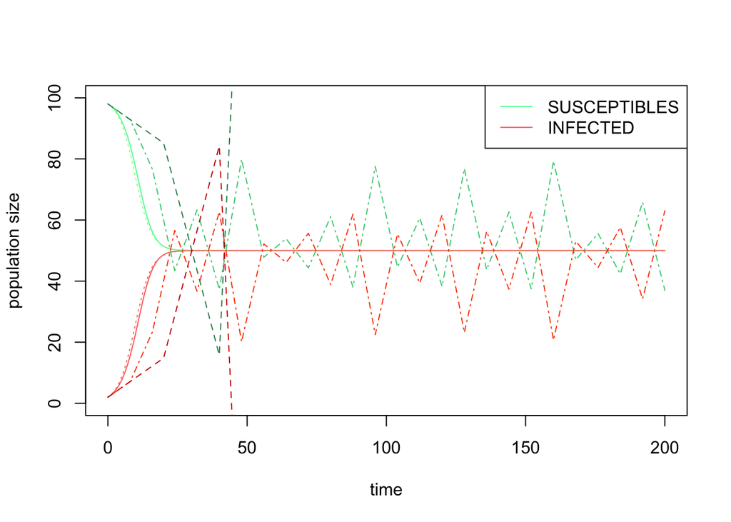

```r
plot_populations(herd.df, col = c("seagreen1", "indianred1"))
plot_populations(herd.df.a, new.graph = FALSE, col = c("palegreen", "salmon"), lty = "dotted")
plot_populations(herd.df.b, new.graph = FALSE, col = c("seagreen3", "orangered"), lty = "dotdash")
plot_populations(herd.df.c, new.graph = FALSE, col = c("seagreen", "red3"), lty = "dashed")
```

## Conclusion

We can see from the figure that the difference between the lines where we modelled the population daily vs at weekly intervals is not very different, although there is some difference so the daily timestep model is more accurate. Given that the difference is so small, it is unlikely that reducing our timesteps to less than one week would be worthwhile, given the limited increase in accuracy and significant increase in computing power. However, we can see that at eight weeks the line no longer accvurately represents the population as the timesteps are too large, then at 20-week timesteps the model no longer produces a line that looks anything like what it should!

In this case I would suggest that one week is probably an appropriate timestep to choose, as we know there is already some loss of accuracy compared to daily, however the lines look pretty similar. It may be appropriate to use a slightly longer timestep (something between one and eight weeks), however we risk further reductions in accuracy for a likely minimal decrease in computing power and time.